# 1D Normal Modes

Once again I've been inspired by my friend Rhett Allain who has been working on the 2 mass/3 spring eigenvalue problem. [Check out his most recent video](https://www.youtube.com/watch?v=Evje62-5q0k).

What I want to do is something [I've blogged a little about before](https://arundquist.wordpress.com/2014/05/09/finding-normal-modes/), but in 1D it ought to be a little easier.

The main approach is to set up a system and then shake it a tiny bit at either a single frequency (which we'll adjust) or a bunch of frequencies at once (that makes the analysis harder). What I'll do is imagine Rhett's system where the so-called fixed red dot on the left will actually be driven wiht a tiny amplitude.

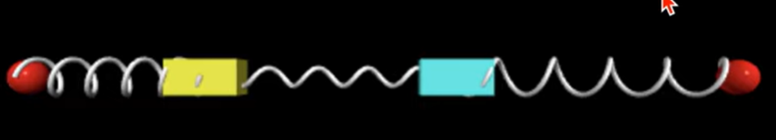

Ok, let's get started. I'll do the usual Lagrangian approach and we'll drive the left edge at a single sinusoidal frequency to start. Note that `x1[t]` and `x2[t]` will be measured from their natural starting position:

```python
k1=1;
k2=2;
k3=3;
m1=1;
m2=2;
l1=l2=l3=1;
drive=1;
left[t_]:=0.1 Sin[drive t];
KE=1/2 m1 x1'[t]^2+1/2 m2 x2'[t]^2;
PE=1/2 k1 (x1[t]-left[t])^2+1/2 k2 (x2[t]-x1[t])^2+1/2 k3 (x2[t])^2;
L=KE-PE;
el[a_]:=D[L, a[t]]-D[L, a'[t],t]==0;
sol=First[NDSolve[{el/@{x1,x2},
        x1[0]==0,
        x2[0]==0,
        x1'[0]==0,
        x2'[0]==0},{x1,x2}, {t,0,tmax=100}]];
```

Here's a plot of the two variables (x1 in blue, x2 in orange):

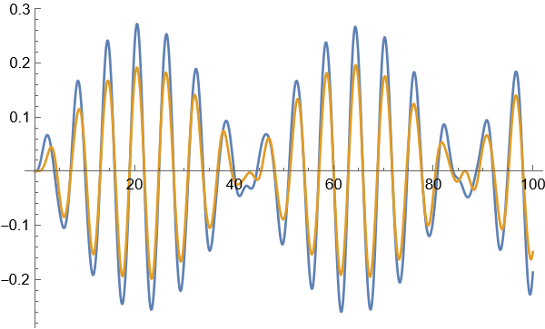

```python
Plot[{x1[t]/.sol, x2[t]/.sol}, {t,0,tmax}]
```

Here's a movie of that:

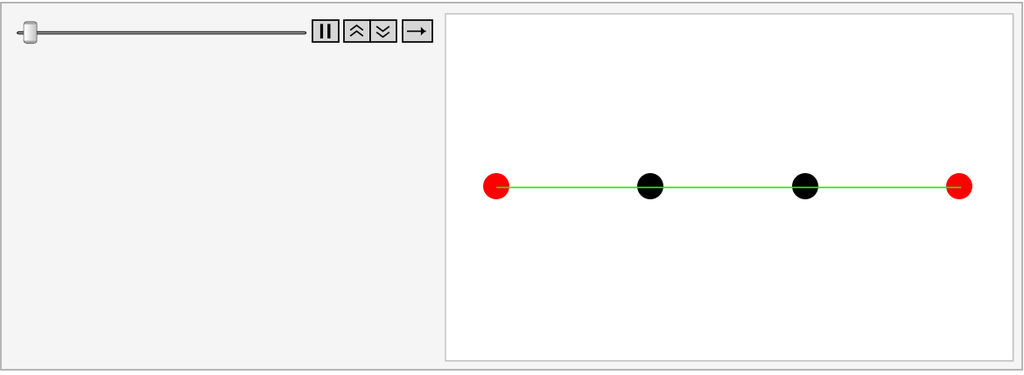

```python
frames=Table[Graphics[{PointSize[0.05],
                        Red,
                        Point[{left[t],0}/.sol],
                        Black,
                        Point[{l1+x1[t],0}/.sol],
                        Point[{l1+l2+x2[t],0}/.sol],
                        Red,
                        Point[{l1+l2+l3,0}],
                        Green,
                        Line[{ {left[t],0},{l1+l2+l3,0}}]}, PlotRange->{ {-0.2, l1+l2+l3+0.2}, {-1,1}}],
                    {t,0,tmax,tmax/100}];
ListAnimate[frames]
```

Ok, that's a little fast, but you get the point.

So, to find the resonances, we could do a couple of different things:

## 1 - Try a bunch and see who causes the biggest response

I'll turn my ODE solver code into a function that returns the highest amplitue of x1 and x2 (maybe summed?) so that I can hunt for big ones:

```python
Clear[singleFrequency]
singleFrequency[{k1_,k2_,k3_}, {m1_,m2_}, {l1_,l2_,l3_}][drive_?NumericQ]:=(
    left[t_]:=0.1 Sin[drive t];
    KE=1/2 m1 x1'[t]^2+1/2 m2 x2'[t]^2;
    PE=1/2 k1 (x1[t]-left[t])^2+1/2 k2 (x2[t]-x1[t])^2+1/2 k3 (x2[t])^2;
    L=KE-PE;
    el[a_]:=D[L, a[t]]-D[L, a'[t],t]==0;
    {sol, {steps}}=Reap[First[NDSolve[{el/@{x1,x2},
            x1[0]==0,
            x2[0]==0,
            x1'[0]==0,
            x2'[0]==0},{x1,x2}, {t,0,tmax=20},
            StepMonitor :> Sow[{Abs[x1[t]], Abs[x2[t]]}]]]];
    Max[steps[[All,1]]]+Max[steps[[All,2]]]
    )
```

```python
singleFrequency[{1,2,3}, {1,2},{1,1,1}][1]
```

```
0.439052
```

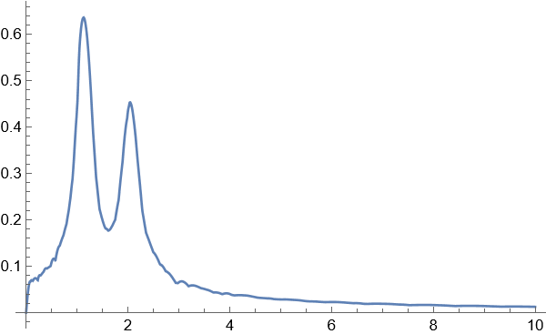

```python
Plot[singleFrequency[{1,2,3}, {1,2},{1,1,1}][omega], {omega,0,10},PlotRange->All]
```

Aha! You can see two clear resonances! So this works pretty well, though it's a little slow (that cell took about a minute to run). Let's see what the two peaks look like:

```python
first=FindMaximum[singleFrequency[{1,2,3}, {1,2},{1,1,1}][omega],{omega,1.1}]
second=FindMaximum[singleFrequency[{1,2,3}, {1,2},{1,1,1}][omega],{omega,2.0}]
```

[output not shown]

[output not shown]

[output not shown]

Ok, now we know the omegas that lead to a peak. Let's look at the mass locations for those:

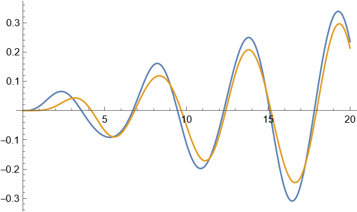

```python
singleFrequency[{1,2,3}, {1,2},{1,1,1}][1.12989]
Plot[{x1[t]/.sol, x2[t]/.sol}, {t,0,20}]
```

They're growing together and in phase, which is usually what you expect for the lower resonance.

Now the second one:

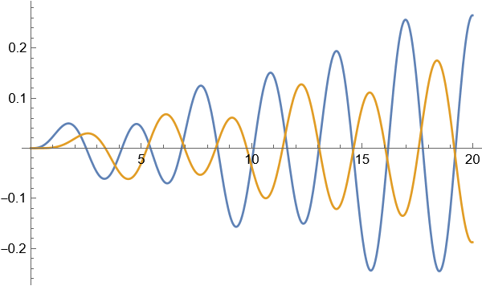

```python
singleFrequency[{1,2,3}, {1,2},{1,1,1}][2.04046]
Plot[{x1[t]/.sol, x2[t]/.sol}, {t,0,20}]
```

As expected, they're both growing and are 180 degrees out of phase. Cool!

Here's a movie of both of those:

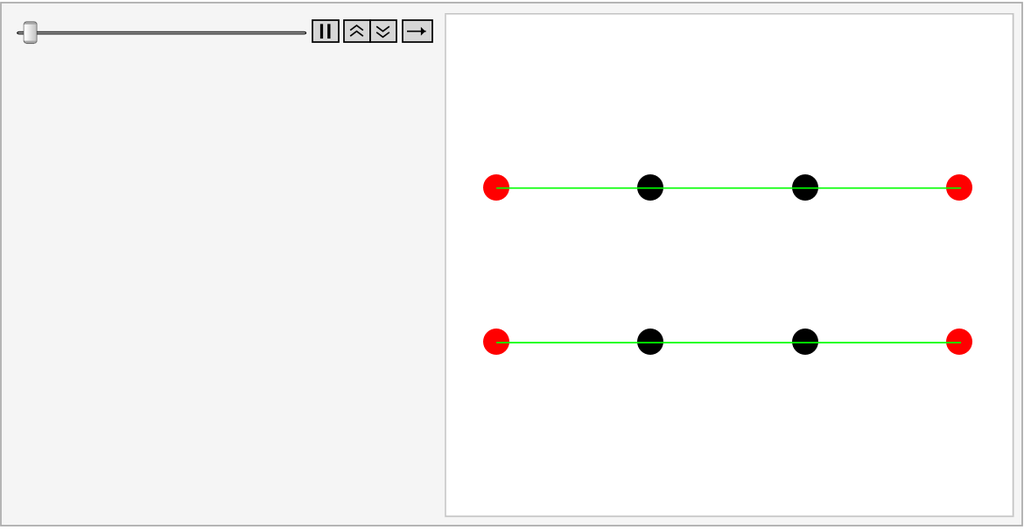

```python
tmp=singleFrequency[{1,2,3}, {1,2},{1,1,1}][1.12989];
sol1=sol;
tmp=singleFrequency[{1,2,3}, {1,2},{1,1,1}][2.04046];
sol2=sol;
singleFrame[sol_,shift_,omega_][t_]:=Graphics[{PointSize[0.05],
                        Red,
                        Point[{0.1 Sin[omega t],shift}/.sol],
                        Black,
                        Point[{l1+x1[t],shift}/.sol],
                        Point[{l1+l2+x2[t],shift}/.sol],
                        Red,
                        Point[{l1+l2+l3,shift}],
                        Green,
                        Line[{ {0.1 Sin[omega t],shift},{l1+l2+l3,shift}}]}, PlotRange->{ {-0.2, l1+l2+l3+0.2}, {-1,2}}]
frames=Table[Show[singleFrame[sol1,0, 1.12989][t], singleFrame[sol2,1, 2.04046][t]],{t,0,tmax,tmax/100}];
ListAnimate[frames]
```

## 2 - Excite them with all frequencies at once

Here I'll move the left red ball quickly in a linear fashion and then quickly return it to zero. Then I'll Fourier Transform the results to see the frequency spectrum

```python
k1=1;
k2=2;
k3=3;
m1=1;
m2=2;
l1=l2=l3=1;
drive=1;
left[t_]:=Piecewise[{ {10 t, t<0.01},{0.1-10(t-0.01), t<0.02}}];
KE=1/2 m1 x1'[t]^2+1/2 m2 x2'[t]^2;
PE=1/2 k1 (x1[t]-left[t])^2+1/2 k2 (x2[t]-x1[t])^2+1/2 k3 (x2[t])^2;
L=KE-PE;
el[a_]:=D[L, a[t]]-D[L, a'[t],t]==0;
sol=First[NDSolve[{el/@{x1,x2},
        x1[0]==0,
        x2[0]==0,
        x1'[0]==0,
        x2'[0]==0},{x1,x2}, {t,0,tmax=100}]];
```

Here's a plot of the left edge zoomed in to the first tenth of a second of time:

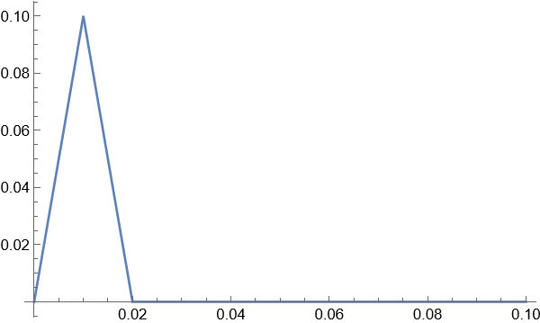

```python
Plot[left[t],{t,0,.1},PlotRange->All]
```

and here's a plot of x1 and x2

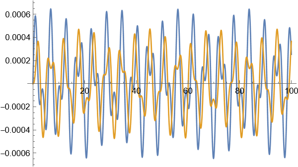

```python
Plot[{x1[t]/.sol,x2[t]/.sol},{t,0,tmax}]
```

They don't have a lot of amplitude, but it's enough for a Fourier Transform:

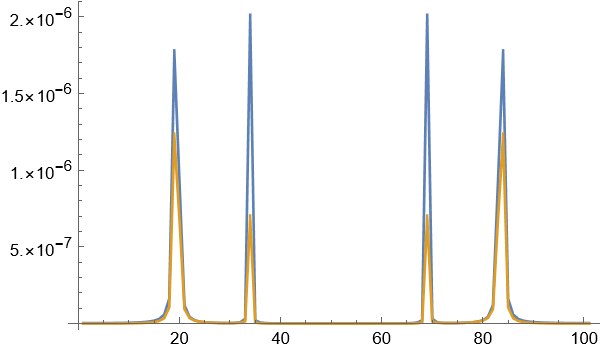

```python
xdata=Table[x1[t]/.sol,{t,0,tmax,tmax/100}];
ydata=Table[x2[t]/.sol,{t,0,tmax,tmax/100}];
xFT=Fourier[xdata];
yFT=Fourier[ydata];
ListLinePlot[{Abs[xFT]^2, Abs[yFT]^2},PlotRange->All]
```

See, two peaks! (I know, I know, it looks like four, but that's because of the dumb way most fft (fast fourier transforms) work). Really you should just show the first half of the data if the original data is composed of real numbers, which this data set is:

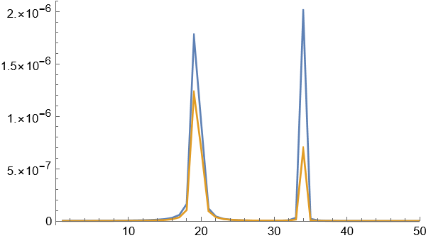

```python
ListLinePlot[{Abs[xFT]^2, Abs[yFT]^2},PlotRange->{ {0,50}, All}]
```

There, see, 2 peaks!

So how do you get the properly scaled frequencies from a discrete fft? Well, every point represents a frequency, with the first one being zero and then they're all spaced by $\frac{2\pi}{\Delta t}$ where $\Delta t$ it to total time that the data spans.

So first we have to find the peak locations:

```python
FindPeaks[Abs[xFT]^2]
```

```
                -6                 -6                 -6                  -6
{{19, 1.76219 10  }, {34, 1.9945 10  }, {69, 1.9945 10  }, {84, 1.76219 10  }}
```

So we have a peak in the 19th and 34th position. That means that the first one is 18 of the frequency spacings:

```python
2 Pi (19-1)*1./(tmax)
```

```
1.13097
```

and the second on is at 33 of the frequency spacings:

```python
2 Pi (34-1)*1./(tmax)
```

```
2.07345
```

They're both pretty darn close to what we found before, and we did by just doing the ode solver once!

## Your thoughts?

I'd love to hear your thoughts. Here are some starters for you:

1. This is great! I especially like . . .
2. This is dumb! What's truly dumb is . . .
3. I saw Rhett posted about a 3-mass system on twitter. Why are you so slow?
4. I don't understand why the `Fourier` command duplicates the data for real values
5. Wait, the Wolfram Engines starts counting lists at one and not zero? That's crazy!
6. What's with those warnings after the `FindMaximum` commands?
7. Why do you do option 2 with a triangle pulse? Would something else work better?
8. I don't think summing the max amplitudes of x1 and x2 is the right way to measure the resonances. A better way would be . . .